# DSP 110 Project - Comic Character Analysis

# Setup and Data Loading

```r
library(readr)
library(dplyr)
library(tidyr)
library(lubridate)
library(janitor)
library(coursekata)
library(curl)
```

## Load Data from GitHub

```r
# Get DC characters:
comic_characters_dc <-
  "https://github.com/fivethirtyeight/data/raw/master/comic-characters/dc-wikia-data.csv" %>%
  read_csv() %>%
  clean_names() %>%
  mutate(publisher = "DC")

# Get Marvel characters:
comic_characters_marvel <-
  "https://github.com/fivethirtyeight/data/raw/master/comic-characters/marvel-wikia-data.csv" %>%
  read_csv() %>%
  clean_names() %>%
  mutate(publisher = "Marvel")
```

## Data Wrangling

```r
# Merge two datasets and perform further data wrangling:
comic_characters <-
  comic_characters_dc %>%
  bind_rows(comic_characters_marvel) %>%
  separate(first_appearance, c("year2", "month"), ", ", remove = FALSE) %>%
  mutate(
    # If month was missing, set as January and day as 01:
    month = ifelse(is.na(month), "01", month),
    day = "01",
    # Note some years missing:
    date = ymd(paste(year, month, day, sep = "-")),
    align = factor(
      align,
      levels = c("Bad Characters", "Reformed Criminals", "Netural Characters", "Good Characters"),
      ordered = TRUE)
  ) %>%
  select(publisher, everything(), -c(year2, day))
```

```r
str(comic_characters)
```

```
tibble [23,272 × 16] (S3: tbl_df/tbl/data.frame)
 $ publisher       : chr [1:23272] "DC" "DC" "DC" "DC" ...
 $ page_id         : num [1:23272] 1422 23387 1458 1659 1576 ...
 $ name            : chr [1:23272] "Batman (Bruce Wayne)" "Superman (Clark Kent)" "Green Lantern (Hal Jordan)" "James Gordon (New Earth)" ...
 $ urlslug         : chr [1:23272] "\\/wiki\\/Batman_(Bruce_Wayne)" "\\/wiki\\/Superman_(Clark_Kent)" "\\/wiki\\/Green_Lantern_(Hal_Jordan)" "\\/wiki\\/James_Gordon_(New_Earth)" ...
 $ id              : chr [1:23272] "Secret Identity" "Secret Identity" "Secret Identity" "Public Identity" ...
 $ align           : Ord.factor w/ 4 levels "Bad Characters"<..: 4 4 4 4 4 4 4 4 4 4 ...
 $ eye             : chr [1:23272] "Blue Eyes" "Blue Eyes" "Brown Eyes" "Brown Eyes" ...
 $ hair            : chr [1:23272] "Black Hair" "Black Hair" "Brown Hair" "White Hair" ...
 $ sex             : chr [1:23272] "Male Characters" "Male Characters" "Male Characters" "Male Characters" ...
 $ gsm             : chr [1:23272] NA NA NA NA ...
 $ alive           : chr [1:23272] "Living Characters" "Living Characters" "Living Characters" "Living Characters" ...
 $ appearances     : num [1:23272] 3093 2496 1565 1316 1237 ...
 $ first_appearance: chr [1:23272] "1939, May" "1986, October" "1959, October" "1987, February" ...
 $ month           : chr [1:23272] "May" "October" "October" "February" ...
 $ year            : num [1:23272] 1939 1986 1959 1987 1940 ...
 $ date            : Date[1:23272], format: "1939-05-01" "1986-10-01" "1959-10-01" ...
```

```r
head(comic_characters)
```

| publisher | page_id | name | urlslug | id | align | eye | hair | sex | gsm | alive | appearances | first_appearance | month | year | date |
| --- | --- | --- | --- | --- | --- | --- | --- | --- | --- | --- | --- | --- | --- | --- | --- |
| DC | 1422 | Batman (Bruce Wayne) | \\/wiki\\/Batman_(Bruce_Wayne) | Secret Identity | Good Characters | Blue Eyes | Black Hair | Male Characters | NA | Living Characters | 3093 | 1939, May | May | 1939 | 1939-05-01 |
| DC | 23387 | Superman (Clark Kent) | \\/wiki\\/Superman_(Clark_Kent) | Secret Identity | Good Characters | Blue Eyes | Black Hair | Male Characters | NA | Living Characters | 2496 | 1986, October | October | 1986 | 1986-10-01 |
| DC | 1458 | Green Lantern (Hal Jordan) | \\/wiki\\/Green_Lantern_(Hal_Jordan) | Secret Identity | Good Characters | Brown Eyes | Brown Hair | Male Characters | NA | Living Characters | 1565 | 1959, October | October | 1959 | 1959-10-01 |
| DC | 1659 | James Gordon (New Earth) | \\/wiki\\/James_Gordon_(New_Earth) | Public Identity | Good Characters | Brown Eyes | White Hair | Male Characters | NA | Living Characters | 1316 | 1987, February | February | 1987 | 1987-02-01 |
| DC | 1576 | Richard Grayson (New Earth) | \\/wiki\\/Richard_Grayson_(New_Earth) | Secret Identity | Good Characters | Blue Eyes | Black Hair | Male Characters | NA | Living Characters | 1237 | 1940, April | April | 1940 | 1940-04-01 |
| DC | 1448 | Wonder Woman (Diana Prince) | \\/wiki\\/Wonder_Woman_(Diana_Prince) | Public Identity | Good Characters | Blue Eyes | Black Hair | Female Characters | NA | Living Characters | 1231 | 1941, December | December | 1941 | 1941-12-01 |

## Data Cleaning

Figure out the unique classes for all the variables we’ll be using: sex / gender, public identity, alive status, and alignment in order to clean them.

```r
unique(comic_characters$sex)
```

```
[1] "Male Characters"        "Female Characters"      NA
[4] "Genderless Characters"  "Transgender Characters" "Genderfluid Characters"
[7] "Agender Characters"
```

```r
unique(comic_characters$id)
```

```
[1] "Secret Identity"               "Public Identity"
[3] NA                              "Identity Unknown"
[5] "No Dual Identity"              "Known to Authorities Identity"
```

```r
unique(comic_characters$alive)
```

```
[1] "Living Characters"   "Deceased Characters" NA
```

```r
unique(comic_characters$align)
```

```
[1] Good Characters    Bad Characters     <NA>               Reformed Criminals
Levels: Bad Characters < Reformed Criminals < Netural Characters < Good Characters
```

Shorten the class names for cleaner plotting

```r
comic_clean <- comic_characters %>%
  mutate(
    sex = recode(
      sex,
      "Male Characters" = "Male",
      "Female Characters" = "Female",
      "Agender Characters" = "Agender",
      "Genderfluid Characters" = "Genderfluid",
      "Genderless Characters" = "Genderless",
      "Transgender Characters" = "Transgender"
    ),

    alive = recode(
      alive,
      "Living Characters" = "Living",
      "Deceased Characters" = "Deceased"
    ),

    align = recode(
      align,
      "Bad Characters" = "Bad",
      "Reformed Criminals" = "Reformed",
      "Neutral Characters" = "Neutral",
      "Good Characters" = "Good"
))
```

```r
total_rows <- nrow(comic_characters)

sex_missing <- sum(is.na(comic_characters$sex))
id_missing <- sum(is.na(comic_characters$id))
alive_missing <- sum(is.na(comic_characters$alive))
align_missing <- sum(is.na(comic_characters$align))

cat("Missing values for each variable:\n")
```

```
Missing values for each variable:
```

```r
cat(sprintf("- Sex missing: %d (%.2f%%)\n",
            sex_missing, 100 * sex_missing / total_rows))
```

```
- Sex missing: 979 (4.21%)
```

```r
cat(sprintf("- Identity missing: %d (%.2f%%)\n",
            id_missing, 100 * id_missing / total_rows))
```

```
- Identity missing: 5783 (24.85%)
```

```r
cat(sprintf("- Alive status missing: %d (%.2f%%)\n",
            alive_missing, 100 * alive_missing / total_rows))
```

```
- Alive status missing: 6 (0.03%)
```

```r
cat(sprintf("- Alignment missing: %d (%.2f%%)\n",
            align_missing, 100 * align_missing / total_rows))
```

```
- Alignment missing: 6186 (26.58%)
```

# Data Exploration

## Explore Characters by Publisher

```r
comic_clean %>%
count(publisher) %>%
arrange(desc(n))
```

| publisher | n |
| --- | --- |
| Marvel | 16376 |
| DC | 6896 |

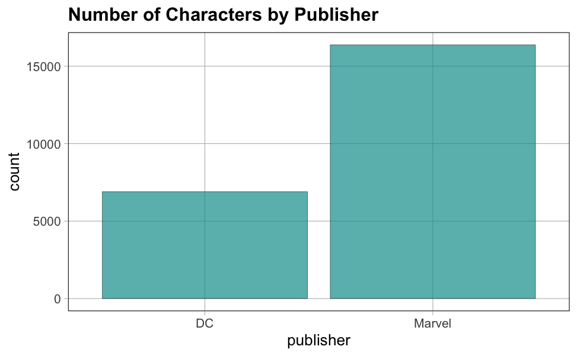

```r
gf_bar(~publisher, data = comic_clean) %>%
gf_labs(title = "Number of Characters by Publisher")
```

## Explore Characters by Gender

```r
comic_clean %>%
count(sex) %>%
arrange(desc(n))
```

| sex | n |
| --- | --- |
| Male | 16421 |
| Female | 5804 |
| NA | 979 |
| Agender | 45 |
| Genderless | 20 |
| Genderfluid | 2 |
| Transgender | 1 |

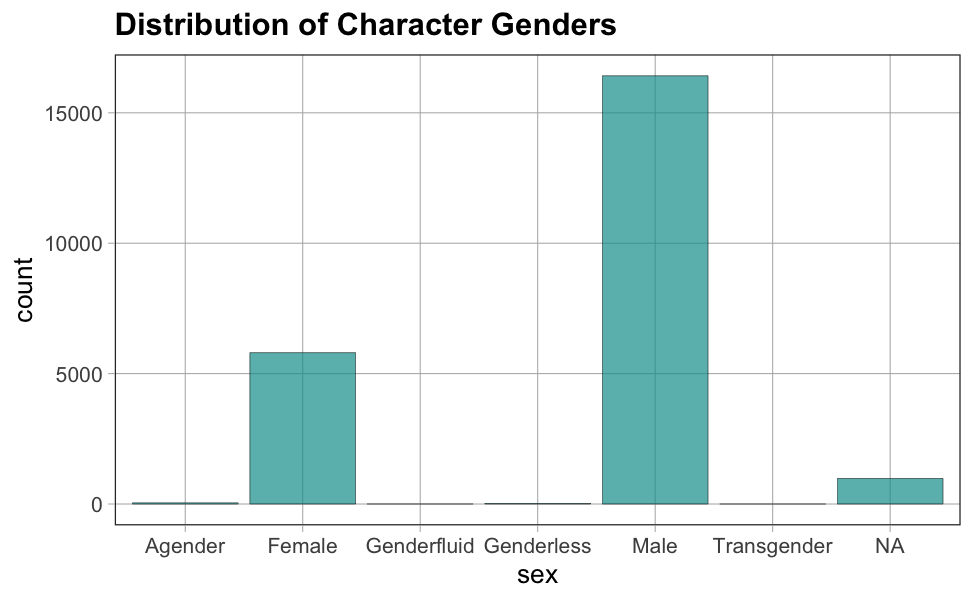

```r
gf_bar(~sex, data = comic_clean) %>%
gf_labs(title = "Distribution of Character Genders")
```

## Explore Characters by Public Identity

```r
comic_clean %>%
count(id) %>%
arrange(desc(n))
```

| id | n |
| --- | --- |
| Secret Identity | 8683 |
| Public Identity | 6994 |
| NA | 5783 |
| No Dual Identity | 1788 |
| Known to Authorities Identity | 15 |
| Identity Unknown | 9 |

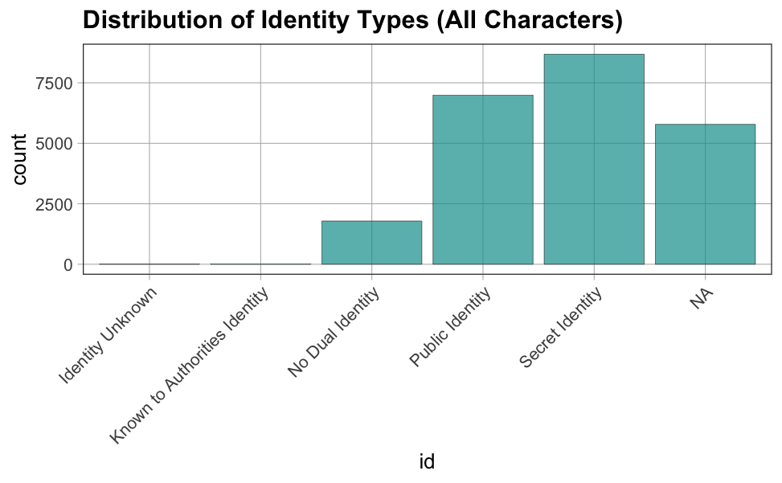

```r
plot <- gf_bar(~id, data = comic_clean) %>%
gf_labs(title = "Distribution of Identity Types (All Characters)")

plot + theme(axis.text.x = element_text(angle = 45, hjust = 1))
```

## Explore Characters by Moral Alignment

```r
comic_clean %>%
count(align) %>%
arrange(desc(n))
```

| align | n |
| --- | --- |
| Bad | 9615 |
| Good | 7468 |
| NA | 6186 |
| Reformed | 3 |

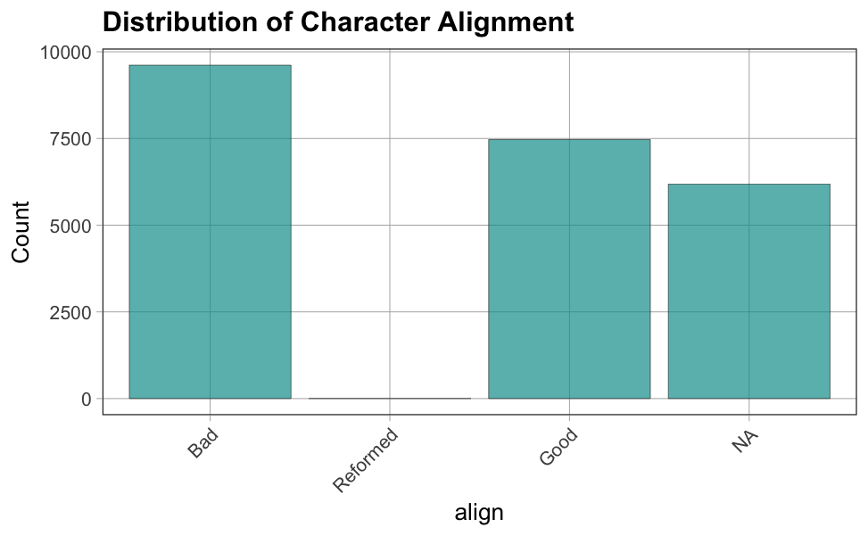

```r
plot <- gf_bar(~align, data = comic_clean) %>%
  gf_labs(title = "Distribution of Character Alignment",
          y = "Count")

plot + theme(axis.text.x = element_text(angle = 45, hjust = 1))
```

# Research Question 1: Does gender influence secret identity status?

Now that we’ve explored the different distributions of main variables a character can have, we explore if certain characters are more likely to have a secret identity based on their gender. We limit to male and female characters and public vs. secret identities based on those classes dominating the dataset.

```r
by_gender_MF <- comic_clean %>%
  filter(sex %in% c("Male", "Female"))
```

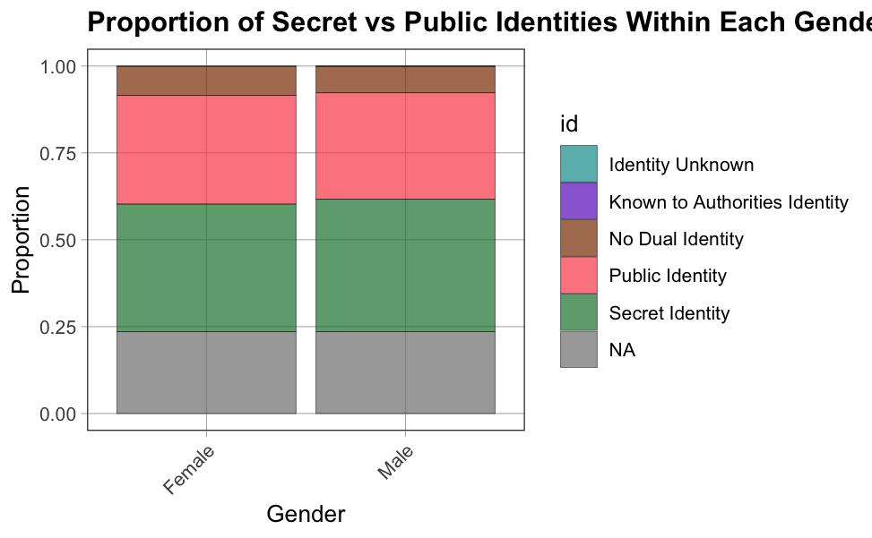

```r
by_gender_MF %>%
  gf_bar(~sex, fill = ~id, position = "fill") %>%
  gf_labs(
    title = "Proportion of Secret vs Public Identities Within Each Gender",
    y = "Proportion",
    x = "Gender"
  ) +
  theme(axis.text.x = element_text(angle = 45, hjust = 1))
```

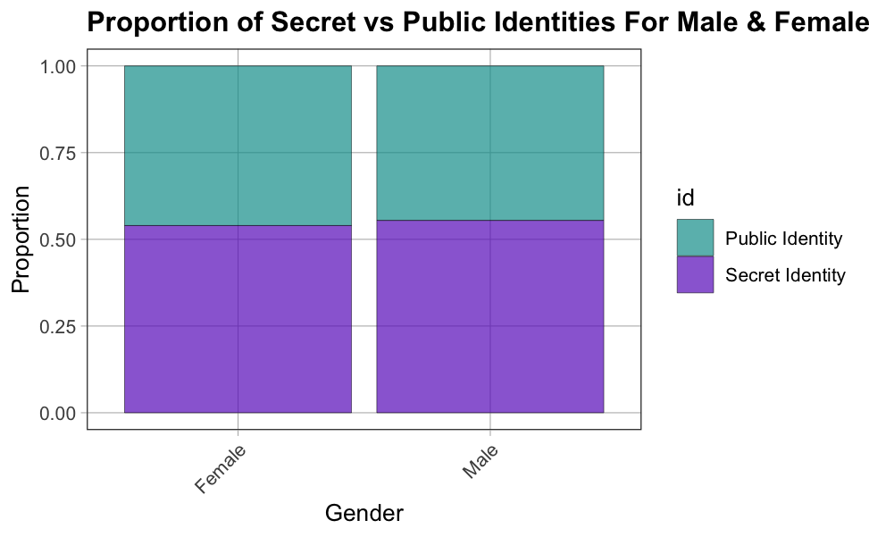

```r
by_gender_MF %>%
  filter(id %in% c("Secret Identity", "Public Identity")) %>%
  gf_bar(~sex, fill = ~id, position = "fill") %>%
  gf_labs(
    title = "Proportion of Secret vs Public Identities For Male & Female",
    y = "Proportion",
    x = "Gender"
  ) +
  theme(axis.text.x = element_text(angle = 45, hjust = 1))
```

## Calculate Probabilities

```r
prob_table <- by_gender_MF %>%
  filter(id %in% c("Secret Identity", "Public Identity")) %>%
  count(sex, id) %>%
  group_by(sex) %>%
  mutate(prop = n / sum(n)) %>%
  filter(sex %in% c("Male", "Female"),
         id == "Secret Identity")

prob_table
```

| sex | id | n | prop |
| --- | --- | --- | --- |
| Female | Secret Identity | 2130 | 0.5397871 |
| Male | Secret Identity | 6257 | 0.5544037 |

```r
p_secret_male <- prob_table$prop[prob_table$sex == "Male"]
p_secret_female <- prob_table$prop[prob_table$sex == "Female"]
diff_secret <- p_secret_male - p_secret_female

cat("P(Secret | Male)   =", round(p_secret_male, 4), "\n")
```

```
P(Secret | Male)   = 0.5544
```

```r
cat("P(Secret | Female) =", round(p_secret_female, 4), "\n")
```

```
P(Secret | Female) = 0.5398
```

```r
cat("Difference =", round(diff_secret, 4), "\n")
```

```
Difference = 0.0146
```

## Conclusions

We wanted to know if a character’s sex/gender affects their likelihood of having a secret identity, whether P(Secret | Male) is approximately equal to P(Secret | Female). If those two probabilities are roughly equal then gender and identity status can be considered independent.

Male and female characters dominate the dataset when it comes to the sex variable. There is not enough data to make a meaningful conclusion about any of the other gendered characters given the distributions in section 1 .

There is a notable imbalance of about a 3:1 ratio of male to female characters in this dataset, but their proportion of secret identities are almost identical.

Since P(Secret | Male) = 0.55 and P(Secret | Female) = 0.54, the difference in proportions P(Secret | Male) - P(Secret | Female) = 0.0146. We can reasonably conclude that P(Secret | Gender) approximately equals P(Secret), meaning gender and secret identity status appear approximately independent in this dataset. We can conclude that knowing a character’s gender gives little information about whether they have a secret identity.

# Research Question 2: Have more female or male characters appeared in comics over time?

We know from the preliminary EDA that more male characters have appeared over time but this question is trying to understand:

1. How many characters were introduced each year for each gender?
2. Is the number increasing over time and how strongly?
3. Does the trend differ between male and female characters?

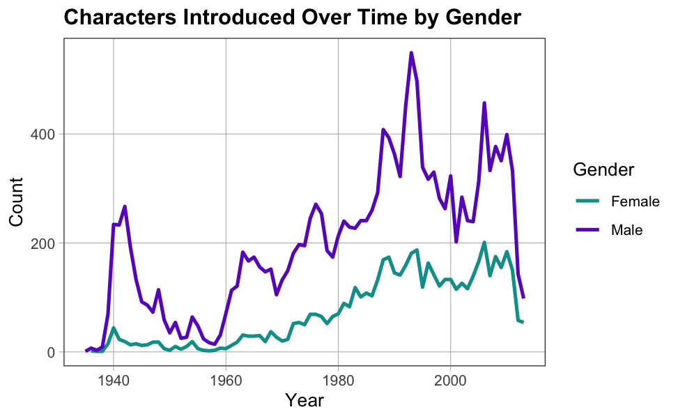

```r
# Filter for male and female characters that have a valid year introduced
gender_year <- comic_clean %>%
  filter(sex %in% c("Male", "Female"),
         !is.na(year)) %>%
  mutate(year = as.numeric(year))

# Count the number per gender each year
gender_counts <- gender_year %>%
  group_by(year, sex) %>%
  summarise(count = n(), .groups = "drop")

# Plot a line graph for both genders
gf_line(count ~ year, color = ~sex, data = gender_counts) %>%
  gf_labs(
    title = "Characters Introduced Over Time by Gender",
    x = "Year",
    y = "Count",
    color = "Gender"
  )
```

## Linear Model

```r
male_counts <- gender_counts %>% filter(sex == "Male")
female_counts <- gender_counts %>% filter(sex == "Female")

model_male <- lm(count ~ year, data = male_counts)
model_female <- lm(count ~ year, data = female_counts)

summary(model_male)
```

```
Call:
lm(formula = count ~ year, data = male_counts)

Residuals:
    Min      1Q  Median      3Q     Max
-264.53  -42.74  -10.85   34.61  269.59

Coefficients:
              Estimate Std. Error t value Pr(>|t|)
(Intercept) -8003.7182   864.2486  -9.261 3.77e-14 ***
year            4.1561     0.4378   9.493 1.35e-14 ***
---
Signif. codes:  0 ‘***’ 0.001 ‘**’ 0.01 ‘*’ 0.05 ‘.’ 0.1 ‘ ’ 1

Residual standard error: 88.73 on 77 degrees of freedom
Multiple R-squared:  0.5393,    Adjusted R-squared:  0.5333
F-statistic: 90.13 on 1 and 77 DF,  p-value: 1.347e-14
```

```r
summary(model_female)
```

```
Call:
lm(formula = count ~ year, data = female_counts)

Residuals:
    Min      1Q  Median      3Q     Max
-108.14  -19.10   -4.81   17.76   69.60

Coefficients:
              Estimate Std. Error t value Pr(>|t|)
(Intercept) -4578.4221   317.2135  -14.43   <2e-16 ***
year            2.3550     0.1606   14.66   <2e-16 ***
---
Signif. codes:  0 ‘***’ 0.001 ‘**’ 0.01 ‘*’ 0.05 ‘.’ 0.1 ‘ ’ 1

Residual standard error: 31.94 on 76 degrees of freedom
Multiple R-squared:  0.7387,    Adjusted R-squared:  0.7353
F-statistic: 214.9 on 1 and 76 DF,  p-value: < 2.2e-16
```

To examine whether male or female characters were introduced more frequently over time, we counted all characters by gender for each year and applied linear models.

Male characters produced a positive slope of 4.16 with a p value < 1e-13, meaning publishers introduced about 4 additional male characters each year. The model explains 54% of the variation (R² = 0.539).

Female introductions also increased significantly over time, with a slope of 2.36 and a p value p < 2e-16. Female characters introduced rose more consistently (R² = 0.739), though the total numbers were always lower than male characters.

While both genders show strong upward trends, male characters grow faster in absolute terms. However, because the female model fits better, the growth in female characters is more stable over time. Female representation increased especially after 1980, even though proportion of males remained dominant.